# 2018 Pakistani General Election: polling station long data codebook

## [Current .csv file](https://osf.io/2sdzg/download) - v0.1

### Changelog

- [v0.1](https://osf.io/2sdzg/download)
  - First public release

### Citation

Sonnet, Luke. 2019. “2018 Pakistani General Election Polling Station Data.” https://doi.org/10.17605/osf.io/mtsnd.

## Automatically generated codebook

### Metadata

#### Description

**Dataset name**: 2018 Pakistani General Elections Polling Station Level Data (long)

### Overview

These data are the official form 48s (polling station level returns by candidate), and are a reshaped version of the wide polling station data. They are made long so that each row is a polling station-candidate. For more thorough documentation of the data, please see the wide data page.

### Variable summary

Identifiers:

- constituency_id
- constituency_ps_id: the pasted together constituency_id and ps_id, a unique identifier of the constituency-polling station

Polling station level data:

- ps_total_votes: reported number of invalid and valid votes on form 48
- ps_invalid_votes: reported number of invalid votes on form 48
- ps_valid_votes: reported number of valid votes on form 48
- ps_valid_votes_summed: the summed number of `candidate_votes` in the polling station. This may differ from `ps_valid_votes` if there are errors in any of the candidate totals or in the `ps_valid_votes` field

Candidate level data:

- candidate_id: id number, unique to the consituency, that matches the column number in the wide data
- candidate_name
- candidate_party
- candidate_votes: the number of valid votes cast for this candidate at this polling station
- candidate_valid_share: the candidates vote share of the reported total number of polling station valid votes (`candidate_votes / ps_valid_votes`)
- candidate_valid_share_of_summed: the candidates vote share of the summed candidate-level valid votes (`candidate_votes / ps_valid_votes_summed`)

Other data:

- candidate_total_valid_votes_summed: the constituency-level sum of `candidate_votes` for a candidate
- candidate_total_valid_votes_polled_49: the constituency-level total votes polled by this candidate as reported on the constituency-level form 49s. This may differ from `candidate_total_valid_votes_summed` if some polling stations are missing or there are errors in any of the polling station level candidate vote totals.
- n_candidates: the number of candidates competing in the constituency

**Metadata for search engines**

- **Citation**: Sonnet, Luke. 2019. “2018 Pakistani General Election Polling Station Data.” https://doi.org/10.17605/osf.io/mtsnd.
- **URL**: https://osf.io/mtsnd/
- **Identifier**: https://osf.io/mtsnd/
- **Date published**: 2019-10-21
- **Creator**:
  - **@type**: Person
  - **givenName**: Luke
  - **familyName**: Sonnet
  - **email**: luke.sonnet@gmail.com
- **keywords**: *constituency_id*, *constituency_ps_id*, *candidate_id*, *candidate_name*, *candidate_party*, *candidate_votes*, *candidate_valid_share*, *candidate_valid_share_of_summed*, *candidate_total_valid_votes_summed*, *candidate_total_valid_votes_polled_49*, *ps_invalid_votes*, *ps_valid_votes*, *ps_total_votes*, *ps_valid_votes_summed* and *n_candidates*

### Variables

#### constituency_id

##### Distribution

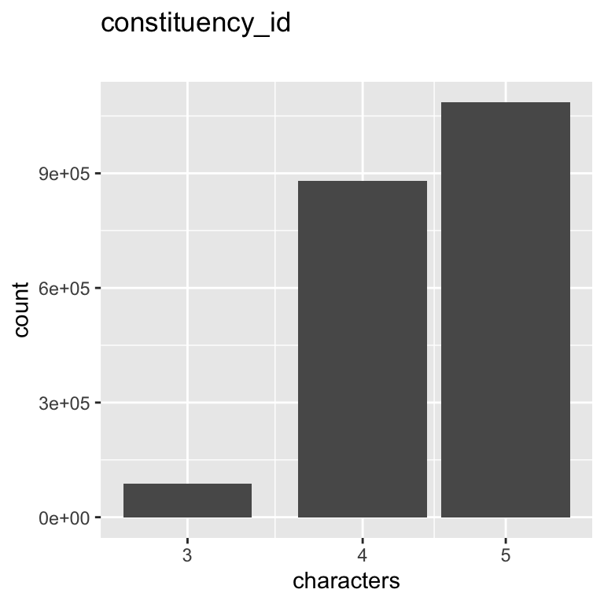

0 missing values.

##### Summary statistics

| name | data_type | missing | complete | n | empty | n_unique | min | max |
| --- | --- | --- | --- | --- | --- | --- | --- | --- |
| constituency_id | character | 0 | 2052980 | 2052980 | 0 | 792 | 3 | 5 |

#### constituency_ps_id

##### Distribution

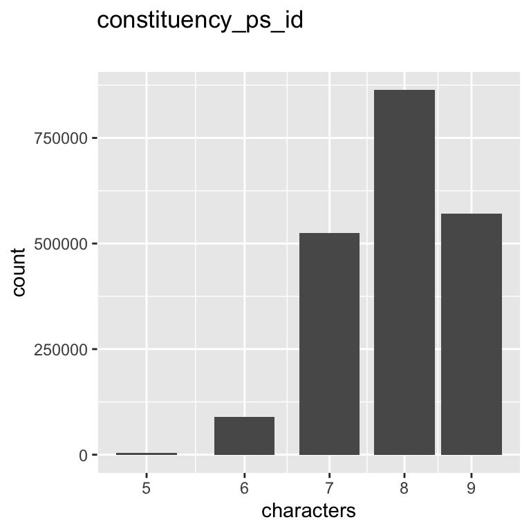

0 missing values.

##### Summary statistics

| name | data_type | missing | complete | n | empty | n_unique | min | max |
| --- | --- | --- | --- | --- | --- | --- | --- | --- |
| constituency_ps_id | character | 0 | 2052980 | 2052980 | 0 | 156114 | 5 | 9 |

#### candidate_id

##### Distribution

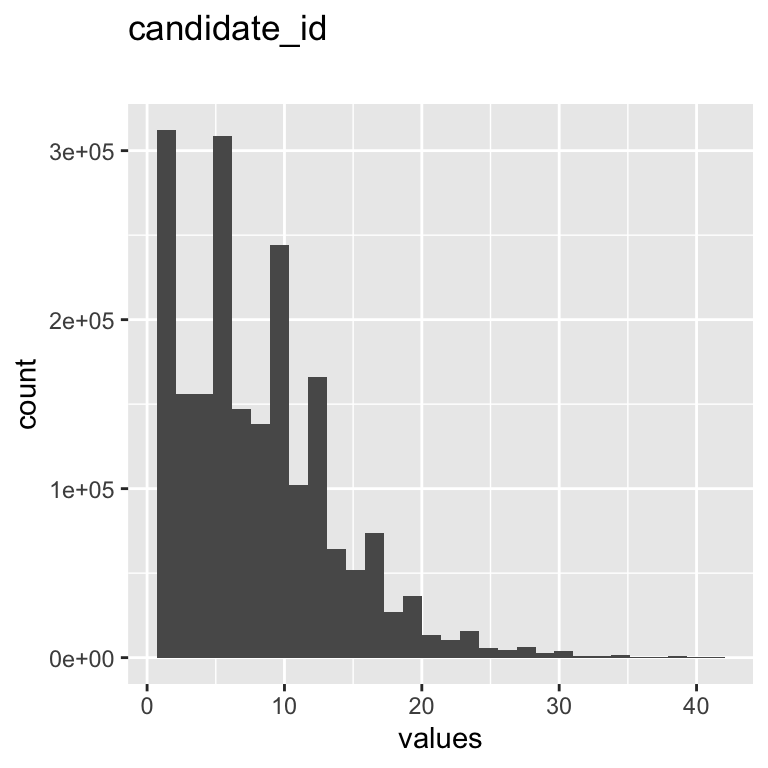

0 missing values.

##### Summary statistics

| name | data_type | missing | complete | n | mean | sd | p0 | p25 | p50 | p75 | p100 | hist |
| --- | --- | --- | --- | --- | --- | --- | --- | --- | --- | --- | --- | --- |
| candidate_id | integer | 0 | 2052980 | 2052980 | 8.14 | 5.64 | 1 | 4 | 7 | 11 | 41 | ▇▆▃▁▁▁▁▁ |

#### candidate_name

##### Distribution

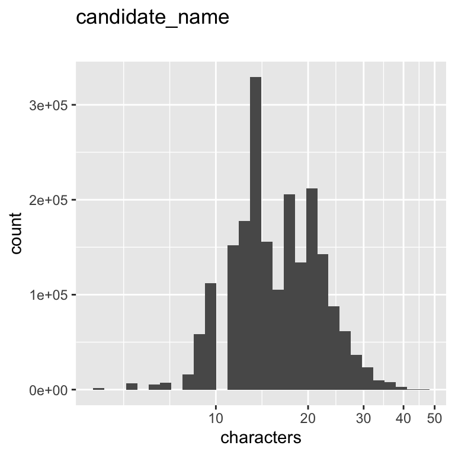

0 missing values.

##### Summary statistics

| name | data_type | missing | complete | n | empty | n_unique | min | max |
| --- | --- | --- | --- | --- | --- | --- | --- | --- |
| candidate_name | character | 0 | 2052980 | 2052980 | 0 | 8232 | 4 | 48 |

#### candidate_party

##### Distribution

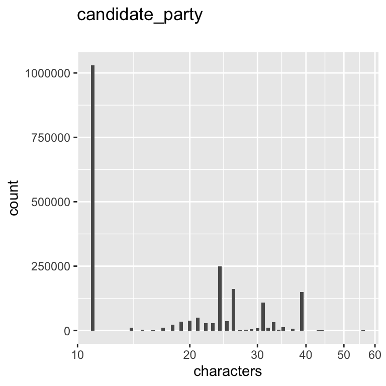

0 missing values.

##### Summary statistics

| name | data_type | missing | complete | n | empty | n_unique | min | max |
| --- | --- | --- | --- | --- | --- | --- | --- | --- |
| candidate_party | character | 0 | 2052980 | 2052980 | 0 | 95 | 11 | 56 |

#### candidate_votes

##### Distribution

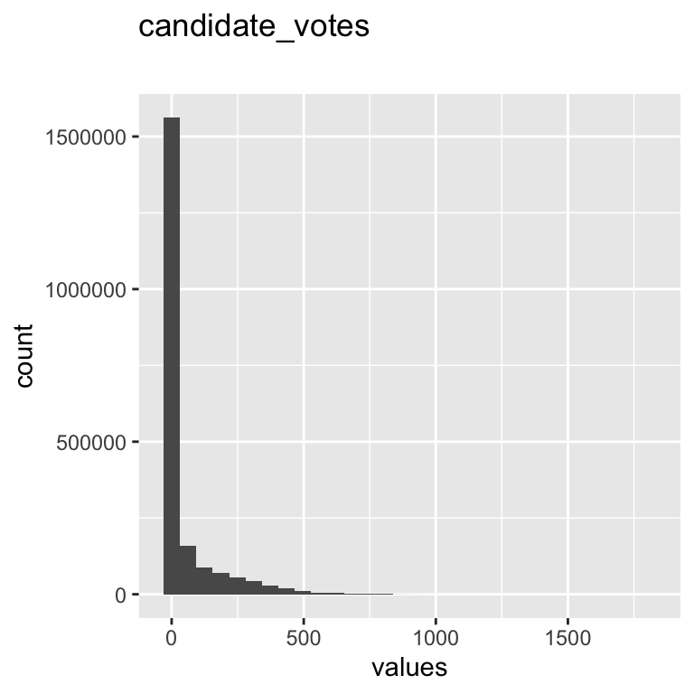

3811 missing values.

##### Summary statistics

| name | data_type | missing | complete | n | mean | sd | p0 | p25 | p50 | p75 | p100 | hist |
| --- | --- | --- | --- | --- | --- | --- | --- | --- | --- | --- | --- | --- |
| candidate_votes | integer | 3811 | 2049169 | 2052980 | 47.95 | 106.13 | 0 | 0 | 2 | 27 | 1803 | ▇▁▁▁▁▁▁▁ |

#### candidate_valid_share

##### Distribution

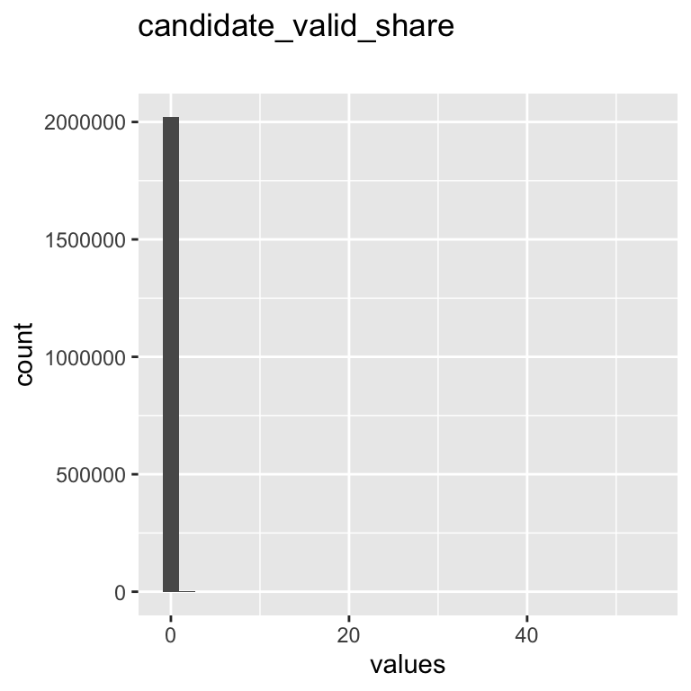

29828 missing values.

##### Summary statistics

| name | data_type | missing | complete | n | mean | sd | p0 | p25 | p50 | p75 | p100 | hist |
| --- | --- | --- | --- | --- | --- | --- | --- | --- | --- | --- | --- | --- |
| candidate_valid_share | numeric | 29828 | 2023152 | 2052980 | 0.076 | 0.16 | 0 | 0 | 0.0038 | 0.047 | 53.25 | ▇▁▁▁▁▁▁▁ |

#### candidate_valid_share_of_summed

##### Distribution

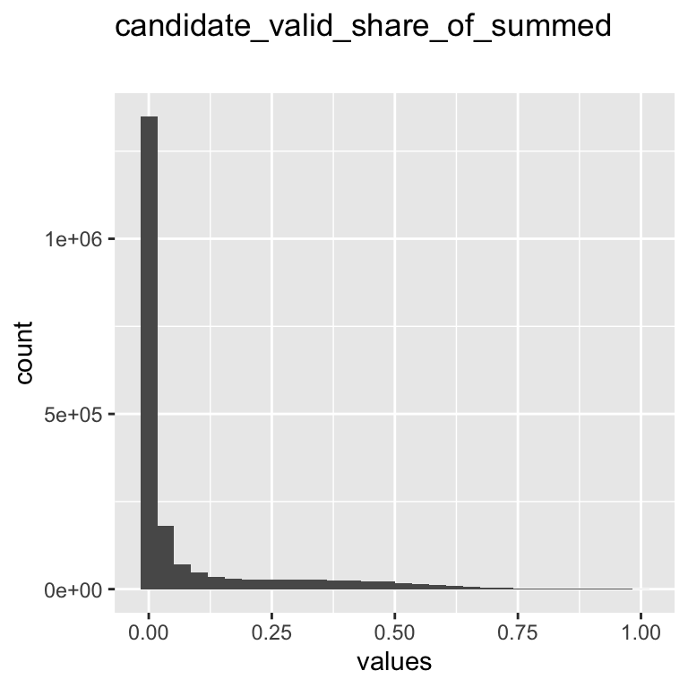

32130 missing values.

##### Summary statistics

| name | data_type | missing | complete | n | mean | sd | p0 | p25 | p50 | p75 | p100 | hist |
| --- | --- | --- | --- | --- | --- | --- | --- | --- | --- | --- | --- | --- |
| candidate_valid_share_of_summed | numeric | 32130 | 2020850 | 2052980 | 0.076 | 0.16 | 0 | 0 | 0.0039 | 0.047 | 1 | ▇▁▁▁▁▁▁▁ |

#### candidate_total_valid_votes_summed

##### Distribution

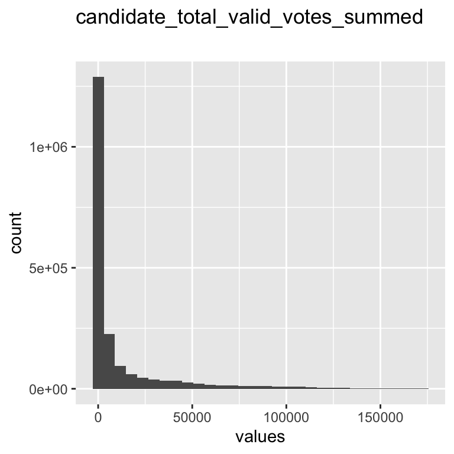

53339 missing values.

##### Summary statistics

| name | data_type | missing | complete | n | mean | sd | p0 | p25 | p50 | p75 | p100 | hist |
| --- | --- | --- | --- | --- | --- | --- | --- | --- | --- | --- | --- | --- |
| candidate_total_valid_votes_summed | integer | 53339 | 1999641 | 2052980 | 11795.6 | 25111.36 | 0 | 202 | 1024 | 8160 | 172609 | ▇▁▁▁▁▁▁▁ |

#### candidate_total_valid_votes_polled_49

##### Distribution

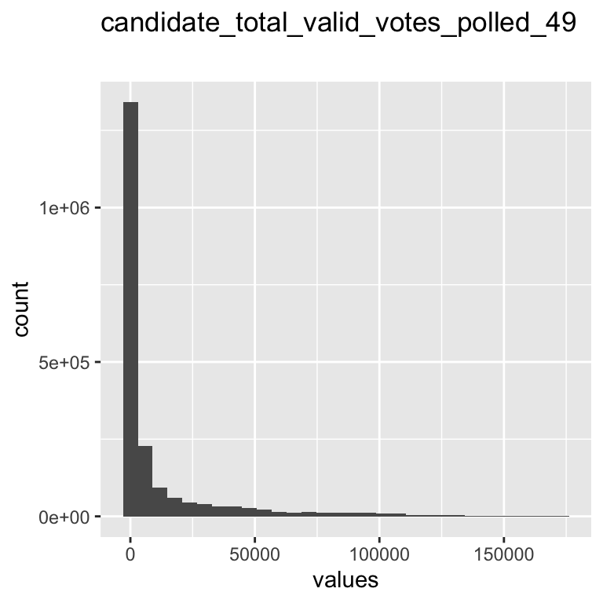

0 missing values.

##### Summary statistics

| name | data_type | missing | complete | n | mean | sd | p0 | p25 | p50 | p75 | p100 | hist |
| --- | --- | --- | --- | --- | --- | --- | --- | --- | --- | --- | --- | --- |
| candidate_total_valid_votes_polled_49 | integer | 0 | 2052980 | 2052980 | 11390.08 | 24594.08 | -99 | 179 | 951 | 7657 | 173125 | ▇▁▁▁▁▁▁▁ |

#### ps_invalid_votes

##### Distribution

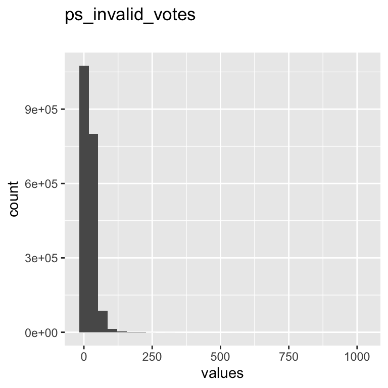

71340 missing values.

##### Summary statistics

| name | data_type | missing | complete | n | mean | sd | p0 | p25 | p50 | p75 | p100 | hist |
| --- | --- | --- | --- | --- | --- | --- | --- | --- | --- | --- | --- | --- |
| ps_invalid_votes | integer | 71340 | 1981640 | 2052980 | 20.57 | 18.77 | 0 | 9 | 16 | 27 | 1016 | ▇▁▁▁▁▁▁▁ |

#### ps_valid_votes

##### Distribution

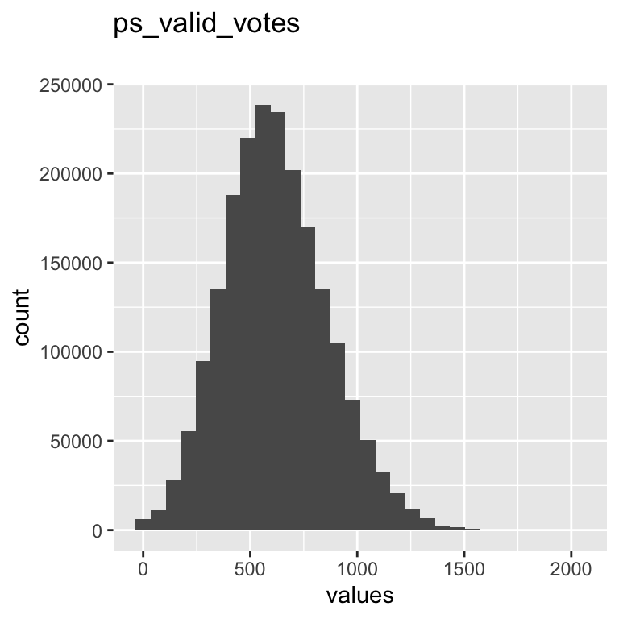

26625 missing values.

##### Summary statistics

| name | data_type | missing | complete | n | mean | sd | p0 | p25 | p50 | p75 | p100 | hist |
| --- | --- | --- | --- | --- | --- | --- | --- | --- | --- | --- | --- | --- |
| ps_valid_votes | integer | 26625 | 2026355 | 2052980 | 620.99 | 244.29 | 0 | 450 | 605 | 777 | 2028 | ▁▆▇▅▁▁▁▁ |

#### ps_total_votes

##### Distribution

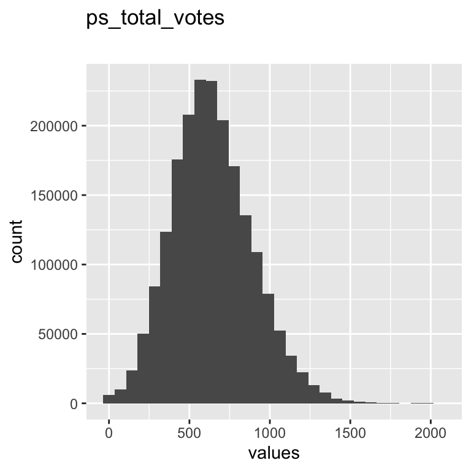

71306 missing values.

##### Summary statistics

| name | data_type | missing | complete | n | mean | sd | p0 | p25 | p50 | p75 | p100 | hist |
| --- | --- | --- | --- | --- | --- | --- | --- | --- | --- | --- | --- | --- |
| ps_total_votes | integer | 71306 | 1981674 | 2052980 | 640.95 | 248.63 | 0 | 468 | 625 | 799 | 2053 | ▁▆▇▅▁▁▁▁ |

#### ps_valid_votes_summed

##### Distribution

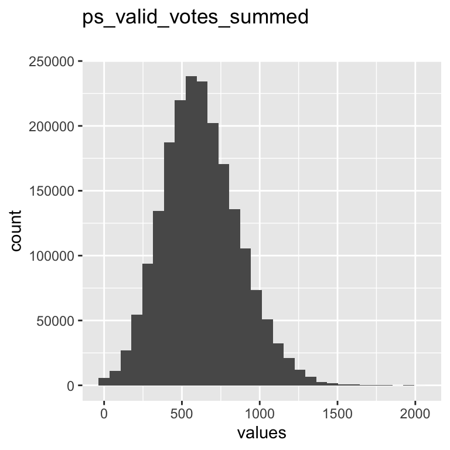

30181 missing values.

##### Summary statistics

| name | data_type | missing | complete | n | mean | sd | p0 | p25 | p50 | p75 | p100 | hist |
| --- | --- | --- | --- | --- | --- | --- | --- | --- | --- | --- | --- | --- |
| ps_valid_votes_summed | integer | 30181 | 2022799 | 2052980 | 622.51 | 243.97 | 0 | 452 | 606 | 778 | 2028 | ▁▆▇▅▁▁▁▁ |

#### n_candidates

##### Distribution

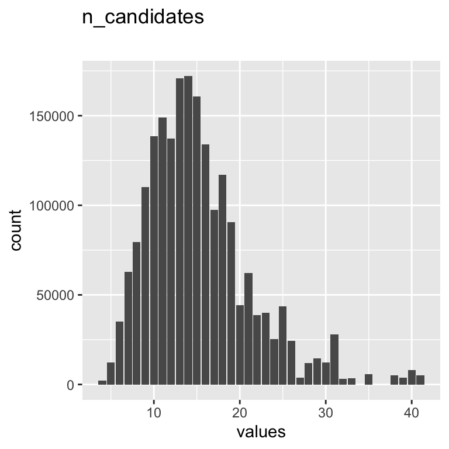

0 missing values.

##### Summary statistics

| name | data_type | missing | complete | n | mean | sd | p0 | p25 | p50 | p75 | p100 | hist |
| --- | --- | --- | --- | --- | --- | --- | --- | --- | --- | --- | --- | --- |
| n_candidates | integer | 0 | 2052980 | 2052980 | 15.27 | 6.12 | 4 | 11 | 14 | 18 | 41 | ▂▇▆▃▂▁▁▁ |

### Codebook table

| name | data_type | missing | complete | n | empty | n_unique | min | max | mean | sd | p0 | p25 | p50 | p75 | p100 | hist |
| --- | --- | --- | --- | --- | --- | --- | --- | --- | --- | --- | --- | --- | --- | --- | --- | --- |
| constituency_id | character | 0 | 2052980 | 2052980 | 0 | 792 | 3 | 5 |  |  |  |  |  |  |  |  |
| constituency_ps_id | character | 0 | 2052980 | 2052980 | 0 | 156114 | 5 | 9 |  |  |  |  |  |  |  |  |
| candidate_id | integer | 0 | 2052980 | 2052980 |  |  |  |  | 8.14 | 5.64 | 1 | 4 | 7 | 11 | 41 | ▇▆▃▁▁▁▁▁ |
| candidate_name | character | 0 | 2052980 | 2052980 | 0 | 8232 | 4 | 48 |  |  |  |  |  |  |  |  |
| candidate_party | character | 0 | 2052980 | 2052980 | 0 | 95 | 11 | 56 |  |  |  |  |  |  |  |  |
| candidate_votes | integer | 3811 | 2049169 | 2052980 |  |  |  |  | 47.95 | 106.13 | 0 | 0 | 2 | 27 | 1803 | ▇▁▁▁▁▁▁▁ |
| candidate_valid_share | numeric | 29828 | 2023152 | 2052980 |  |  |  |  | 0.076 | 0.16 | 0 | 0 | 0.0038 | 0.047 | 53.25 | ▇▁▁▁▁▁▁▁ |
| candidate_valid_share_of_summed | numeric | 32130 | 2020850 | 2052980 |  |  |  |  | 0.076 | 0.16 | 0 | 0 | 0.0039 | 0.047 | 1 | ▇▁▁▁▁▁▁▁ |
| candidate_total_valid_votes_summed | integer | 53339 | 1999641 | 2052980 |  |  |  |  | 11795.6 | 25111.36 | 0 | 202 | 1024 | 8160 | 172609 | ▇▁▁▁▁▁▁▁ |
| candidate_total_valid_votes_polled_49 | integer | 0 | 2052980 | 2052980 |  |  |  |  | 11390.08 | 24594.08 | -99 | 179 | 951 | 7657 | 173125 | ▇▁▁▁▁▁▁▁ |

[output cut: 5 more lines]

**JSON-LD metadata**

The following JSON-LD can be found by search engines, if you share this codebook publicly on the web.

```json
{
  "name": "2018 Pakistani General Elections Polling Station Level Data (long)",
  "description": "\n### Overview\n\nThese data are the official form 48s (polling station level returns by candidate), and are a reshaped version of the wide polling station data. They are made long so that each row is a polling station-candidate. For more thorough documentation of the data, please see the wide data page.\n\n### Variable summary\n\nIdentifiers:\n\n* constituency_id\n* constituency_ps_id: the pasted together constituency_id and ps_id, a unique identifier of the constituency-polling station\n\nPolling station level data:\n\n* ps_total_votes: reported number of invalid and valid votes on form 48\n* ps_invalid_votes: reported number of invalid votes on form 48\n* ps_valid_votes: reported number of valid votes on form 48\n* ps_valid_votes_summed: the summed number of `candidate_votes` in the polling station. This may differ from `ps_valid_votes` if there are errors in any of the candidate totals or in the `ps_valid_votes` field\n\nCandidate level data:\n\n* candidate_id: id number, unique to the consituency, that matches the column number in the wide data\n* candidate_name\n* candidate_party\n* candidate_votes: the number of valid votes cast for this candidate at this polling station\n* candidate_valid_share: the candidates vote share of the reported total number of polling station valid votes (`candidate_votes / ps_valid_votes`)\n* candidate_valid_share_of_summed: the candidates vote share of the summed candidate-level valid votes (`candidate_votes / ps_valid_votes_summed`)\n\nOther data:\n\n* candidate_total_valid_votes_summed: the constituency-level sum of `candidate_votes` for a candidate \n* candidate_total_valid_votes_polled_49: the constituency-level total votes polled by this candidate as reported on the constituency-level form 49s. This may differ from `candidate_total_valid_votes_summed` if some polling stations are missing or there are errors in any of the polling station level candidate vote totals.\n\n* n_candidates: the number of candidates competing in the constituency\n\n\n\n## Table of variables\nThis table contains variable names, labels, their central tendencies and other attributes.\n\n|name                                  |data_type |missing |complete |n       |empty |n_unique |min |max |mean     |sd       |p0  |p25 |p50    |p75   |p100   |hist     |\n|:-------------------------------------|:---------|:-------|:--------|:-------|:-----|:--------|:---|:---|:--------|:--------|:---|:---|:------|:-----|:------|:--------|\n|constituency_id                       |character |0       |2052980  |2052980 |0     |792      |3   |5   |NA       |NA       |NA  |NA  |NA     |NA    |NA     |NA       |\n|constituency_ps_id                    |character |0       |2052980  |2052980 |0     |156114   |5   |9   |NA       |NA       |NA  |NA  |NA     |NA    |NA     |NA       |\n|candidate_id                          |integer   |0       |2052980  |2052980 |NA    |NA       |NA  |NA  |8.14     |5.64     |1   |4   |7      |11    |41     |▇▆▃▁▁▁▁▁ |\n|candidate_name                        |character |0       |2052980  |2052980 |0     |8232     |4   |48  |NA       |NA       |NA  |NA  |NA     |NA    |NA     |NA       |\n|candidate_party                       |character |0       |2052980  |2052980 |0     |95       |11  |56  |NA       |NA       |NA  |NA  |NA     |NA    |NA     |NA       |\n|candidate_votes                       |integer   |3811    |2049169  |2052980 |NA    |NA       |NA  |NA  |47.95    |106.13   |0   |0   |2      |27    |1803   |▇▁▁▁▁▁▁▁ |\n|candidate_valid_share                 |numeric   |29828   |2023152  |2052980 |NA    |NA       |NA  |NA  |0.076    |0.16     |0   |0   |0.0038 |0.047 |53.25  |▇▁▁▁▁▁▁▁ |\n|candidate_valid_share_of_summed       |numeric   |32130   |2020850  |2052980 |NA    |NA       |NA  |NA  |0.076    |0.16     |0   |0   |0.0039 |0.047 |1      |▇▁▁▁▁▁▁▁ |\n|candidate_total_valid_votes_summed    |integer   |53339   |1999641  |2052980 |NA    |NA       |NA  |NA  |11795.6  |25111.36 |0   |202 |1024   |8160  |172609 |▇▁▁▁▁▁▁▁ |\n|candidate_total_valid_votes_polled_49 |integer   |0       |2052980  |2052980 |NA    |NA       |NA  |NA  |11390.08 |24594.08 |-99 |179 |951    |7657  |173125 |▇▁▁▁▁▁▁▁ |\n|ps_invalid_votes                      |integer   |71340   |1981640  |2052980 |NA    |NA       |NA  |NA  |20.57    |18.77    |0   |9   |16     |27    |1016   |▇▁▁▁▁▁▁▁ |\n|ps_valid_votes                        |integer   |26625   |2026355  |2052980 |NA    |NA       |NA  |NA  |620.99   |244.29   |0   |450 |605    |777   |2028   |▁▆▇▅▁▁▁▁ |\n|ps_total_votes                        |integer   |71306   |1981674  |2052980 |NA    |NA       |NA  |NA  |640.95   |248.63   |0   |468 |625    |799   |2053   |▁▆▇▅▁▁▁▁ |\n|ps_valid_votes_summed                 |integer   |30181   |2022799  |2052980 |NA    |NA       |NA  |NA  |622.51   |243.97   |0   |452 |606    |778   |2028   |▁▆▇▅▁▁▁▁ |\n|n_candidates                          |integer   |0       |2052980  |2052980 |NA    |NA       |NA  |NA  |15.27    |6.12     |4   |11  |14     |18    |41     |▂▇▆▃▂▁▁▁ |\n\n### Note\nThis dataset was automatically described using the [codebook R package](https://rubenarslan.github.io/codebook/) (version 0.8.1).",
  "identifier": "https://osf.io/mtsnd/",
  "datePublished": "2019-10-21",
  "creator": {
    "@type": "Person",
    "givenName": "Luke",
    "familyName": "Sonnet",
    "email": "luke.sonnet@gmail.com"
  },
  "citation": "Sonnet, Luke. 2019. “2018 Pakistani General Election Polling Station Data.” https://doi.org/10.17605/osf.io/mtsnd.",
  "url": "https://osf.io/mtsnd/",
  "keywords": ["constituency_id", "constituency_ps_id", "candidate_id", "candidate_name", "candidate_party", "candidate_votes", "candidate_valid_share", "candidate_valid_share_of_summed", "candidate_total_valid_votes_summed", "candidate_total_valid_votes_polled_49", "ps_invalid_votes", "ps_valid_votes", "ps_total_votes", "ps_valid_votes_summed", "n_candidates"],
  "@context": "http://schema.org/",
  "@type": "Dataset",
  "variableMeasured": [
    {
      "name": "constituency_id",
      "@type": "propertyValue"
    },
    {
      "name": "constituency_ps_id",
      "@type": "propertyValue"
    },
    {
      "name": "candidate_id",
      "@type": "propertyValue"
    },
    {
      "name": "candidate_name",
      "@type": "propertyValue"
    },
    {
      "name": "candidate_party",
      "@type": "propertyValue"
    },
    {
      "name": "candidate_votes",
      "@type": "propertyValue"
    },
    {
      "name": "candidate_valid_share",
      "@type": "propertyValue"
    },
    {
      "name": "candidate_valid_share_of_summed",
      "@type": "propertyValue"
    },
    {
      "name": "candidate_total_valid_votes_summed",
      "@type": "propertyValue"
    },
    {
      "name": "candidate_total_valid_votes_polled_49",
      "@type": "propertyValue"
    },
    {
      "name": "ps_invalid_votes",
      "@type": "propertyValue"
    },
    {
      "name": "ps_valid_votes",
      "@type": "propertyValue"
    },
    {
      "name": "ps_total_votes",
      "@type": "propertyValue"
    },
    {
      "name": "ps_valid_votes_summed",
      "@type": "propertyValue"
    },
    {
      "name": "n_candidates",
      "@type": "propertyValue"
    }
  ]
}`
```